# Задача

Расчитать объём репрезентативной выборки для рассылки смс для проекта “Обратная связь”

# Условия

После исполнениях квартирных заявок необходимо производить обзвон клиентов для опроса удовлетворённости оказанными услугами.

Если делать это по всем заявкам, то выходит очень дорого.

## Результаты смс-опроса

В ходе тестирования проекта были получены следующие результаты

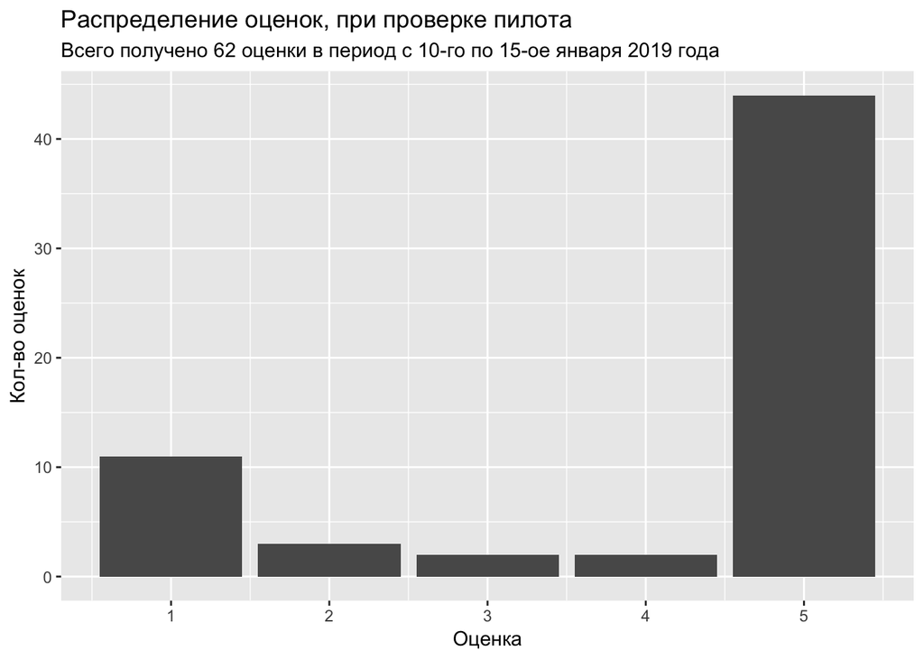

```r
as.tibble(x_real) %>%
ggplot(aes(x_real)) +
  geom_bar() +
  labs(
    x = "Оценка",
    y = "Кол-во оценок",
    title = "Распределение оценок, при проверке пилота",
    subtitle = "Всего получено 62 оценки в период с 10-го по 15-ое января 2019 года"
  )
```

# Генерация генеральной совокупности

Так как распределение оценок статистически не нормальный характер распределения, не имеет смысл вести подсчёт в 5-ти бальной системе.

В дальнейших расчётах для генеральной совокупности, пяти бальная шкала переводилась в бинарную систему оценок. Принималось что оценки 4 и 5 — это 1, остальные — это 0.

Таким образом предлагается считать коэффициент удовлетворённости (`Service Level(SL)`) как отношение положительных оценок к количеству всех полученных оценок

$$SL = \frac{N_{positive}}{N_{positive}+N_{negativ}}\times100\%$$

Генеральная совокупность — это такая гипотетическая выборка, в которой смс были отправлены на все квартирные заявки и все абоненты оценили услуги компании.

Так как нет возможности получить данные о всех оценках, то распределение генеральной совокупности было сгенерировано методом экстраполяции полученных данных.

Cреднемесячный объём квартирных заявок в БЕ брался из исследования Ю. Захаровой.

# Как проводился расчёт

Из генеральной совокупности случайным образом извлекалось случайное колиество элементов.

Количество элементов — это количество получаемых в ответ СМС.

В теории чем выше количество повторов (извлекаемых выборок), тем выше точность. В исследовании извлечение выборок производилось 20 раз — округлённо по числу БЕ.

В каждой выборке рассчитывалось среднее значение и 95% вероятность попасть в доверительный интервал.

Для исследования помимо полученной генеральной совокупности, было сгенерировано ещё три выборки с коэфициентом удовлетворённости равным соответственно 80%, 85%, 90%.

Эти коэффициенты отражают желаемое количество получаемых положительных отзывов.